# day 3-2

このノートブックの実行例はこちら(HTML版)で確認できます

## 0. はじめに

ページ上部のメニューバーにある **Kernel** メニューをクリックし、プルダウンメニューから [**Change Kernel ...**] を選び、**gssm2024:Python** を選択してください。

[figure not shown]

ノートブック上部の右隅に表示されたカーネル名が **gssm2024:Python** になっていることを確認してください。

[figure not shown]

## 3. テキスト解析 (1)

### 3.1 形態素解析

#### 3.1.1 MeCab を使う

##### (1) そのまま出力してみる

```python
import MeCab

tagger = MeCab.Tagger("-r ../tools/usr/local/etc/mecabrc")
print(tagger.parse("今日はいい天気です"))
```

```
今日	名詞,副詞可能,*,*,*,*,今日,キョウ,キョー
は	助詞,係助詞,*,*,*,*,は,ハ,ワ
いい	形容詞,自立,*,*,形容詞・イイ,基本形,いい,イイ,イイ
天気	名詞,一般,*,*,*,*,天気,テンキ,テンキ
です	助動詞,*,*,*,特殊・デス,基本形,です,デス,デス
EOS
```

##### (2) 扱いやすいように Pandas の DataFrame に格納する

```python
import pandas as pd

node = tagger.parseToNode("今日はいい天気です")
features = []
while node:
    features.append(node.feature.split(','))
    node = node.next

columns = [
    "品詞",
    "品詞細分類1",
    "品詞細分類2",
    "品詞細分類3",
    "活用型",
    "活用形",
    "基本形",
    "読み",
    "発音",
]
pd.DataFrame(features, columns=columns)
```

|  | 品詞 | 品詞細分類1 | 品詞細分類2 | 品詞細分類3 | 活用型 | 活用形 | 基本形 | 読み | 発音 |
| --- | --- | --- | --- | --- | --- | --- | --- | --- | --- |
| 0 | BOS/EOS | * | * | * | * | * | * | * | * |
| 1 | 名詞 | 副詞可能 | * | * | * | * | 今日 | キョウ | キョー |
| 2 | 助詞 | 係助詞 | * | * | * | * | は | ハ | ワ |
| 3 | 形容詞 | 自立 | * | * | 形容詞・イイ | 基本形 | いい | イイ | イイ |
| 4 | 名詞 | 一般 | * | * | * | * | 天気 | テンキ | テンキ |
| 5 | 助動詞 | * | * | * | 特殊・デス | 基本形 | です | デス | デス |
| 6 | BOS/EOS | * | * | * | * | * | * | * | * |

### 3.2 係り受け解析

#### 3.2.1 CaboCha を使う

##### (1) そのまま出力してみる

```python
import CaboCha

cp = CaboCha.Parser("-r ../tools/usr/local/etc/cabocharc")
tree = cp.parse("今日はいい天気です")
print(tree.toString(CaboCha.FORMAT_LATTICE))
```

```
* 0 2D 0/1 -1.041733
今日	名詞,副詞可能,*,*,*,*,今日,キョウ,キョー
は	助詞,係助詞,*,*,*,*,は,ハ,ワ
* 1 2D 0/0 -1.041733
いい	形容詞,自立,*,*,形容詞・イイ,基本形,いい,イイ,イイ
* 2 -1D 0/1 0.000000
天気	名詞,一般,*,*,*,*,天気,テンキ,テンキ
です	助動詞,*,*,*,特殊・デス,基本形,です,デス,デス
EOS
```

##### (2) ツリー形式で出力する

```python
print(cp.parseToString("今日はいい天気です"))
```

```
  今日は---D
      いい-D
    天気です
EOS
```

##### (3) 係り受けペアを出力する

```python
# 構文木(tree)からチャンクを取り出す
def get_chunks(tree):
    chunks = {}
    key = 0
    for i in range(tree.size()):
        tok = tree.token(i)
        if tok.chunk:
            chunks[key] = tok.chunk
            key += 1
    return chunks


# チャンク(chunk)から表層形を取り出す
def get_surface(chunk):
    surface = ""
    beg = chunk.token_pos
    end = chunk.token_pos + chunk.token_size
    for i in range(beg, end):
        token = tree.token(i)
        surface += token.surface
    return surface
```

```python
tree = cp.parse("今日はいい天気です")
chunks = get_chunks(tree)

for from_chunk in chunks.values():
    if from_chunk.link < 0:
        continue
    to_chunk = chunks[from_chunk.link]

    from_surface = get_surface(from_chunk)
    to_surface = get_surface(to_chunk)

    print(from_surface, '->', to_surface)
```

```
今日は -> 天気です
いい -> 天気です
```

### 3.3 辞書追加

#### 3.3.1 辞書追加前の確認

(1) 辞書追加前に MeCab の解析結果を確認する

```python
import MeCab

tagger = MeCab.Tagger("-r ../tools/usr/local/etc/mecabrc")
print(tagger.parse("この泉質は極上です"))
print(tagger.parse("この海鮮丼は美味しいです"))
print(tagger.parse("近くにスカイツリーがあります"))
print(tagger.parse("浴室にバスタオルがありません"))
```

```
この	連体詞,*,*,*,*,*,この,コノ,コノ
泉	名詞,一般,*,*,*,*,泉,イズミ,イズミ
質	名詞,接尾,一般,*,*,*,質,シツ,シツ
は	助詞,係助詞,*,*,*,*,は,ハ,ワ
極上	名詞,一般,*,*,*,*,極上,ゴクジョウ,ゴクジョー
です	助動詞,*,*,*,特殊・デス,基本形,です,デス,デス
EOS

この	連体詞,*,*,*,*,*,この,コノ,コノ
海鮮	名詞,一般,*,*,*,*,海鮮,カイセン,カイセン
丼	名詞,一般,*,*,*,*,丼,ドンブリ,ドンブリ
は	助詞,係助詞,*,*,*,*,は,ハ,ワ
美味しい	形容詞,自立,*,*,形容詞・イ段,基本形,美味しい,オイシイ,オイシイ
です	助動詞,*,*,*,特殊・デス,基本形,です,デス,デス
EOS

近く	名詞,副詞可能,*,*,*,*,近く,チカク,チカク
に	助詞,格助詞,一般,*,*,*,に,ニ,ニ
スカイ	名詞,一般,*,*,*,*,スカイ,スカイ,スカイ
ツリー	名詞,一般,*,*,*,*,ツリー,ツリー,ツリー
が	助詞,格助詞,一般,*,*,*,が,ガ,ガ
あり	動詞,自立,*,*,五段・ラ行,連用形,ある,アリ,アリ
ます	助動詞,*,*,*,特殊・マス,基本形,ます,マス,マス
EOS

浴室	名詞,一般,*,*,*,*,浴室,ヨクシツ,ヨクシツ
に	助詞,格助詞,一般,*,*,*,に,ニ,ニ
バス	名詞,一般,*,*,*,*,バス,バス,バス
タオル	名詞,一般,*,*,*,*,タオル,タオル,タオル
が	助詞,格助詞,一般,*,*,*,が,ガ,ガ
あり	動詞,自立,*,*,五段・ラ行,連用形,ある,アリ,アリ
ませ	助動詞,*,*,*,特殊・マス,未然形,ます,マセ,マセ
ん	助動詞,*,*,*,不変化型,基本形,ん,ン,ン
EOS
```

(2) 辞書追加前に CaboCha の解析結果を確認する

```python
import CaboCha

cp = CaboCha.Parser("-r ../tools/usr/local/etc/cabocharc")
print(cp.parse("この泉質は極上です").toString(CaboCha.FORMAT_LATTICE))
print(cp.parse("この海鮮丼は美味しいです").toString(CaboCha.FORMAT_LATTICE))
print(cp.parse("近くにスカイツリーがあります").toString(CaboCha.FORMAT_LATTICE))
print(cp.parse("浴室にバスタオルがありません").toString(CaboCha.FORMAT_LATTICE))
```

```
* 0 1D 0/0 1.423997
この	連体詞,*,*,*,*,*,この,コノ,コノ
* 1 2D 1/2 1.423997
泉	名詞,一般,*,*,*,*,泉,イズミ,イズミ
質	名詞,接尾,一般,*,*,*,質,シツ,シツ
は	助詞,係助詞,*,*,*,*,は,ハ,ワ
* 2 -1D 0/1 0.000000
極上	名詞,一般,*,*,*,*,極上,ゴクジョウ,ゴクジョー
です	助動詞,*,*,*,特殊・デス,基本形,です,デス,デス
EOS

* 0 1D 0/0 1.479074
この	連体詞,*,*,*,*,*,この,コノ,コノ
* 1 2D 1/2 1.479074
海鮮	名詞,一般,*,*,*,*,海鮮,カイセン,カイセン
丼	名詞,一般,*,*,*,*,丼,ドンブリ,ドンブリ
は	助詞,係助詞,*,*,*,*,は,ハ,ワ
* 2 -1D 0/1 0.000000
美味しい	形容詞,自立,*,*,形容詞・イ段,基本形,美味しい,オイシイ,オイシイ
です	助動詞,*,*,*,特殊・デス,基本形,です,デス,デス
EOS

* 0 2D 0/1 -2.105621
近く	名詞,副詞可能,*,*,*,*,近く,チカク,チカク
に	助詞,格助詞,一般,*,*,*,に,ニ,ニ
* 1 2D 1/2 -2.105621
スカイ	名詞,一般,*,*,*,*,スカイ,スカイ,スカイ
ツリー	名詞,一般,*,*,*,*,ツリー,ツリー,ツリー
が	助詞,格助詞,一般,*,*,*,が,ガ,ガ
* 2 -1D 0/1 0.000000
あり	動詞,自立,*,*,五段・ラ行,連用形,ある,アリ,アリ
ます	助動詞,*,*,*,特殊・マス,基本形,ます,マス,マス
EOS

* 0 2D 0/1 -1.725976
浴室	名詞,一般,*,*,*,*,浴室,ヨクシツ,ヨクシツ
に	助詞,格助詞,一般,*,*,*,に,ニ,ニ
* 1 2D 1/2 -1.725976
バス	名詞,一般,*,*,*,*,バス,バス,バス
タオル	名詞,一般,*,*,*,*,タオル,タオル,タオル
が	助詞,格助詞,一般,*,*,*,が,ガ,ガ
* 2 -1D 0/2 0.000000
あり	動詞,自立,*,*,五段・ラ行,連用形,ある,アリ,アリ
ませ	助動詞,*,*,*,特殊・マス,未然形,ます,マセ,マセ
ん	助動詞,*,*,*,不変化型,基本形,ん,ン,ン
EOS
```

#### 3.3.2 辞書追加

(1) 追加したい形態素の情報を CSV ファイル(user_dic.csv)に追記する

```python
!echo '"泉質",-1,-1,1,名詞,一般,*,*,*,*,泉質,センシツ,センシツ,USER"' >> ../tools/usr/local/lib/mecab/dic/ipadic/user_dic.csv
!echo '"海鮮丼",-1,-1,1,名詞,一般,*,*,*,*,海鮮丼,カイセンドン,カイセンドン,USER"' >> ../tools/usr/local/lib/mecab/dic/ipadic/user_dic.csv
!echo '"スカイツリー",-1,-1,1,名詞,一般,*,*,*,*,スカイツリー,スカイツリー,スカイツリー,USER"' >> ../tools/usr/local/lib/mecab/dic/ipadic/user_dic.csv
!echo '"バスタオル",-1,-1,1,名詞,一般,*,*,*,*,バスタオル,バスタオル,バスタオル,USER"' >> ../tools/usr/local/lib/mecab/dic/ipadic/user_dic.csv
!cat ../tools/usr/local/lib/mecab/dic/ipadic/user_dic.csv
```

```
"湯畑",-1,-1,1,名詞,一般,*,*,*,*,湯畑,ユバタケ,ユバタケ,USER"
"泉質",-1,-1,1,名詞,一般,*,*,*,*,泉質,センシツ,センシツ,USER"
"海鮮丼",-1,-1,1,名詞,一般,*,*,*,*,海鮮丼,カイセンドン,カイセンドン,USER"
"スカイツリー",-1,-1,1,名詞,一般,*,*,*,*,スカイツリー,スカイツリー,スカイツリー,USER"
"バスタオル",-1,-1,1,名詞,一般,*,*,*,*,バスタオル,バスタオル,バスタオル,USER"
```

(2) CSVファイル(user_dic.csv)をコンパイルして辞書(user.dic)を作成する

```python
!../tools/usr/local/libexec/mecab/mecab-dict-index \
-d ../tools/usr/local/lib/mecab/dic/ipadic \
-u ../tools/usr/local/lib/mecab/dic/ipadic/user.dic \
-f utf-8 -t utf-8 \
../tools/usr/local/lib/mecab/dic/ipadic/user_dic.csv
```

```
reading ../tools/usr/local/lib/mecab/dic/ipadic/user_dic.csv ... 5
emitting double-array: 100% |###########################################|

done!
```

#### 3.3.3 辞書追加後の確認

(1) 辞書追加後に MeCab の解析結果を確認する

```python
import MeCab

tagger = MeCab.Tagger("-r ../tools/usr/local/etc/mecabrc")
print(tagger.parse("この泉質は極上です"))
print(tagger.parse("この海鮮丼は美味しいです"))
print(tagger.parse("近くにスカイツリーがあります"))
print(tagger.parse("浴室にバスタオルがありません"))
```

```
この	連体詞,*,*,*,*,*,この,コノ,コノ
泉質	名詞,一般,*,*,*,*,泉質,センシツ,センシツ,USER"
は	助詞,係助詞,*,*,*,*,は,ハ,ワ
極上	名詞,一般,*,*,*,*,極上,ゴクジョウ,ゴクジョー
です	助動詞,*,*,*,特殊・デス,基本形,です,デス,デス
EOS

この	連体詞,*,*,*,*,*,この,コノ,コノ
海鮮丼	名詞,一般,*,*,*,*,海鮮丼,カイセンドン,カイセンドン,USER"
は	助詞,係助詞,*,*,*,*,は,ハ,ワ
美味しい	形容詞,自立,*,*,形容詞・イ段,基本形,美味しい,オイシイ,オイシイ
です	助動詞,*,*,*,特殊・デス,基本形,です,デス,デス
EOS

近く	名詞,副詞可能,*,*,*,*,近く,チカク,チカク
に	助詞,格助詞,一般,*,*,*,に,ニ,ニ
スカイツリー	名詞,一般,*,*,*,*,スカイツリー,スカイツリー,スカイツリー,USER"
が	助詞,格助詞,一般,*,*,*,が,ガ,ガ
あり	動詞,自立,*,*,五段・ラ行,連用形,ある,アリ,アリ
ます	助動詞,*,*,*,特殊・マス,基本形,ます,マス,マス
EOS

浴室	名詞,一般,*,*,*,*,浴室,ヨクシツ,ヨクシツ
に	助詞,格助詞,一般,*,*,*,に,ニ,ニ
バスタオル	名詞,一般,*,*,*,*,バスタオル,バスタオル,バスタオル,USER"
が	助詞,格助詞,一般,*,*,*,が,ガ,ガ
あり	動詞,自立,*,*,五段・ラ行,連用形,ある,アリ,アリ
ませ	助動詞,*,*,*,特殊・マス,未然形,ます,マセ,マセ
ん	助動詞,*,*,*,不変化型,基本形,ん,ン,ン
EOS
```

(2) 辞書追加後に CaboCha の解析結果を確認する

```python
import CaboCha

cp = CaboCha.Parser("-r ../tools/usr/local/etc/cabocharc")
print(cp.parse("この泉質は極上です").toString(CaboCha.FORMAT_LATTICE))
print(cp.parse("この海鮮丼は美味しいです").toString(CaboCha.FORMAT_LATTICE))
print(cp.parse("近くにスカイツリーがあります").toString(CaboCha.FORMAT_LATTICE))
print(cp.parse("浴室にバスタオルがありません").toString(CaboCha.FORMAT_LATTICE))
```

```
* 0 1D 0/0 1.509856
この	連体詞,*,*,*,*,*,この,コノ,コノ
* 1 2D 0/1 1.509856
泉質	名詞,一般,*,*,*,*,泉質,センシツ,センシツ,USER"
は	助詞,係助詞,*,*,*,*,は,ハ,ワ
* 2 -1D 0/1 0.000000
極上	名詞,一般,*,*,*,*,極上,ゴクジョウ,ゴクジョー
です	助動詞,*,*,*,特殊・デス,基本形,です,デス,デス
EOS

* 0 1D 0/0 1.479074
この	連体詞,*,*,*,*,*,この,コノ,コノ
* 1 2D 0/1 1.479074
海鮮丼	名詞,一般,*,*,*,*,海鮮丼,カイセンドン,カイセンドン,USER"
は	助詞,係助詞,*,*,*,*,は,ハ,ワ
* 2 -1D 0/1 0.000000
美味しい	形容詞,自立,*,*,形容詞・イ段,基本形,美味しい,オイシイ,オイシイ
です	助動詞,*,*,*,特殊・デス,基本形,です,デス,デス
EOS

* 0 2D 0/1 -2.105621
近く	名詞,副詞可能,*,*,*,*,近く,チカク,チカク
に	助詞,格助詞,一般,*,*,*,に,ニ,ニ
* 1 2D 0/1 -2.105621
スカイツリー	名詞,一般,*,*,*,*,スカイツリー,スカイツリー,スカイツリー,USER"
が	助詞,格助詞,一般,*,*,*,が,ガ,ガ
* 2 -1D 0/1 0.000000
あり	動詞,自立,*,*,五段・ラ行,連用形,ある,アリ,アリ
ます	助動詞,*,*,*,特殊・マス,基本形,ます,マス,マス
EOS

* 0 2D 0/1 -1.728522
浴室	名詞,一般,*,*,*,*,浴室,ヨクシツ,ヨクシツ
に	助詞,格助詞,一般,*,*,*,に,ニ,ニ
* 1 2D 0/1 -1.728522
バスタオル	名詞,一般,*,*,*,*,バスタオル,バスタオル,バスタオル,USER"
が	助詞,格助詞,一般,*,*,*,が,ガ,ガ
* 2 -1D 0/2 0.000000
あり	動詞,自立,*,*,五段・ラ行,連用形,ある,アリ,アリ
ませ	助動詞,*,*,*,特殊・マス,未然形,ます,マセ,マセ
ん	助動詞,*,*,*,不変化型,基本形,ん,ン,ン
EOS
```

## Appendix. データ理解 (Python の場合)

### A.1 データのダウンロード (1度だけ実行)

以下のデータをダウンロードします

| ファイル名 | 件数 | データセット | 備考 |
| --- | --- | --- | --- |
| rakuten-1000-2023-2024.xlsx.zip | 10,000 | •レジャー+ビジネスの 10エリア •エリアごと 1,000件 (ランダムサンプリング) •期間: 2023/1~2024 GW明け | 本講義の全体を通して使用する |

```python
# rakuten-1000-2023-2024.xlsx.zip をダウンロードする
FILE_ID = "1EeCuDrfKdlsMxG9p3Ot7TIxfV9_f2smY"
!gdown --id {FILE_ID}
!unzip -o rakuten-1000-2023-2024.xlsx.zip
```

```python
# # rakuten-1000-2021-2022.xlsx.zip をダウンロードする
# FILE_ID = "1ru2f4vasZBDo6Rt1B9OwMN-eksyqAl7i"
# !gdown --id {FILE_ID}
# !unzip -o rakuten-1000-2021-2022.xlsx.zip
```

### A.2 データの読み込み (DataFrame型)

```python
import pandas as pd

df = pd.read_excel("rakuten-1000-2023-2024.xlsx")
print(df.shape)
display(df.head())
```

```
(10000, 18)
```

|  | カテゴリー | エリア | 施設番号 | 施設名 | コメント | 総合 | サービス | 立地 | 部屋 | 設備・アメニティ | 風呂 | 食事 | 旅行の目的 | 同伴者 | 宿泊年月 | 投稿者 | 年代 | 性別 |
| --- | --- | --- | --- | --- | --- | --- | --- | --- | --- | --- | --- | --- | --- | --- | --- | --- | --- | --- |
| 0 | A_レジャー | 01_登別 | 80732 | 登別カルルス温泉 湯元オロフレ荘 | 彼のリクエストでカルルス温泉に宿泊させていただきました。北海道ラブ割利用でお得に宿泊できる分... | 5 | 5 | 4 | 5 | 5.0 | 5.0 | 5.0 | レジャー | 恋人 | 45231 | 投稿者 | na | na |
| 1 | A_レジャー | 01_登別 | 149334 | 天然温泉 幸鐘の湯 ドーミーイン東室蘭（ドーミーイン・御宿野乃 ホテルズグループ） | 室蘭方面の旅行の時には何度か宿泊しています。ドーミーインのサービスはとても良くて大好きです。... | 4 | 5 | 5 | 2 | 5.0 | 5.0 | 5.0 | レジャー | 家族 | 45413 | 投稿者 | na | na |
| 2 | A_レジャー | 01_登別 | 109022 | 心のリゾート 海の別邸ふる川 | もう一度行きたくなる宿でした。部屋もワンランクアップしていただき感謝しています。お風呂も最高... | 4 | 3 | 5 | 5 | 4.0 | 5.0 | 3.0 | レジャー | 一人 | 45261 | gaku0713 | 60代 | 男性 |
| 3 | A_レジャー | 01_登別 | 7506 | ホテルニューバジェット室蘭 | 居心地良く過ごせました | 4 | 4 | 4 | 4 | 4.0 | 4.0 | 3.0 | レジャー | 一人 | 45200 | 投稿者 | na | na |
| 4 | A_レジャー | 01_登別 | 37380 | 登別温泉 旅亭 花ゆら | 事前カード精算で露天風呂付特別和洋室を予約しましたが別の和室に案内されました。すぐ違うことに... | 1 | 2 | 4 | 2 | 2.0 | 4.0 | 3.0 | レジャー | 家族 | 45323 | 投稿者 | na | na |

### A.3 集計

#### (1) エリア別の件数を表示する

```python
display(df.pivot_table(index=['カテゴリー','エリア'], columns=None, values='コメント', aggfunc='count'))
```

| カテゴリー | エリア | コメント |
| --- | --- | --- |
| A_レジャー | 01_登別 | 1000 |
|  | 02_草津 | 1000 |
|  | 03_箱根 | 1000 |
|  | 04_道後 | 1000 |
|  | 05_湯布院 | 1000 |
| B_ビジネス | 06_札幌 | 1000 |
|  | 07_名古屋 | 1000 |
|  | 08_東京 | 1000 |
|  | 09_大阪 | 1000 |
|  | 10_福岡 | 1000 |

サンプリングデータなので、すべて1000件になっていることを確認する

#### (2) 投稿者の傾向 (年代別x性別、全体で100%)

```python
cross_df = pd.crosstab(df['年代'], df['性別'], margins=True, margins_name='合計', normalize=True) * 100
display(cross_df.loc[:,['男性','女性','na','合計']].style.format('{:.2f}%').bar(axis=None, vmin=0, width=90, height=90, align='left'))
```

| 性別 年代 | 男性 | 女性 | na | 合計 |
| --- | --- | --- | --- | --- |
| 10代 | 0.00% | 0.05% | 0.00% | 0.05% |
| 120代 | 0.00% | 0.01% | 0.00% | 0.01% |
| 20代 | 0.70% | 1.16% | 0.00% | 1.86% |
| 30代 | 1.94% | 2.60% | 0.00% | 4.54% |
| 40代 | 4.54% | 3.76% | 0.00% | 8.30% |
| 50代 | 7.95% | 4.17% | 0.00% | 12.12% |
| 60代 | 6.34% | 1.96% | 0.00% | 8.30% |
| 70代 | 1.38% | 0.36% | 0.00% | 1.74% |
| 80代 | 0.07% | 0.06% | 0.00% | 0.13% |
| na | 0.00% | 0.00% | 62.95% | 62.95% |
| 合計 | 22.92% | 14.13% | 62.95% | 100.00% |

`na` を除いて表示する

```python
cross_df = pd.crosstab(df['年代'], df['性別'], margins=False, normalize=True) * 100
display(cross_df.loc[cross_df.index!='na',['男性','女性']].style.format('{:.2f}%').bar(axis=None, vmin=0, width=90, height=90, align='left'))
```

| 性別 年代 | 男性 | 女性 |
| --- | --- | --- |
| 10代 | 0.00% | 0.05% |
| 120代 | 0.00% | 0.01% |
| 20代 | 0.70% | 1.16% |
| 30代 | 1.94% | 2.60% |
| 40代 | 4.54% | 3.76% |
| 50代 | 7.95% | 4.17% |
| 60代 | 6.34% | 1.96% |
| 70代 | 1.38% | 0.36% |
| 80代 | 0.07% | 0.06% |

#### (3) 投稿者の傾向 (性別xカテゴリ別、列ごとで100%)

```python
cross_df = pd.crosstab(df['性別'], df['カテゴリー'], margins=True, margins_name='合計', normalize='columns') * 100
display(cross_df.loc[['男性','女性','na'],:].style.format('{:.2f}%').bar(axis=None, width=90, height=90, align='left'))
```

| カテゴリー 性別 | A_レジャー | B_ビジネス | 合計 |
| --- | --- | --- | --- |
| 男性 | 22.52% | 23.32% | 22.92% |
| 女性 | 15.98% | 12.28% | 14.13% |
| na | 61.50% | 64.40% | 62.95% |

`na` を除いて表示する

```python
cross_df = pd.crosstab(df['性別'], df['カテゴリー'], margins=False, normalize='columns') * 100
display(cross_df.loc[['男性','女性'],:].style.format('{:.2f}%').bar(axis=None, vmin=0, width=90, height=90, align='left'))
```

| カテゴリー 性別 | A_レジャー | B_ビジネス |
| --- | --- | --- |
| 男性 | 22.52% | 23.32% |
| 女性 | 15.98% | 12.28% |

#### (4) 投稿者の傾向 (性別xエリア別、列ごとで100%)

```python
cross_df = pd.crosstab(df['性別'], [df['カテゴリー'],df['エリア']], margins=True, margins_name='合計', normalize='columns') * 100
display(cross_df.loc[['男性','女性','na'],:].style.format('{:.2f}%'))
```

| カテゴリー エリア 性別 | A_レジャー 01_登別 | A_レジャー 02_草津 | A_レジャー 03_箱根 | A_レジャー 04_道後 | A_レジャー 05_湯布院 | B_ビジネス 06_札幌 | B_ビジネス 07_名古屋 | B_ビジネス 08_東京 | B_ビジネス 09_大阪 | B_ビジネス 10_福岡 | 合計 |
| --- | --- | --- | --- | --- | --- | --- | --- | --- | --- | --- | --- |
| 男性 | 24.10% | 22.80% | 16.20% | 27.10% | 22.40% | 26.40% | 25.30% | 21.30% | 20.50% | 23.10% | 22.92% |
| 女性 | 16.00% | 16.00% | 17.20% | 11.40% | 19.30% | 12.70% | 12.90% | 11.70% | 11.80% | 12.30% | 14.13% |
| na | 59.90% | 61.20% | 66.60% | 61.50% | 58.30% | 60.90% | 61.80% | 67.00% | 67.70% | 64.60% | 62.95% |

カラーバーにすると横に長くなるため、ヒートマップでプロットする

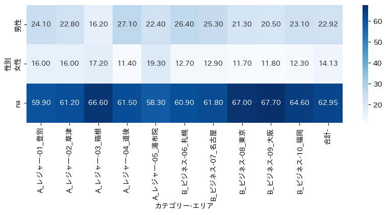

```python
import seaborn as sns
import matplotlib.pyplot as plt
import japanize_matplotlib

plt.figure(figsize=(10,3))
sns.heatmap(cross_df.loc[['男性','女性','na'],:], annot=True, fmt='.2f', cmap='Blues')
plt.show()
```

`na` を除いてプロットする

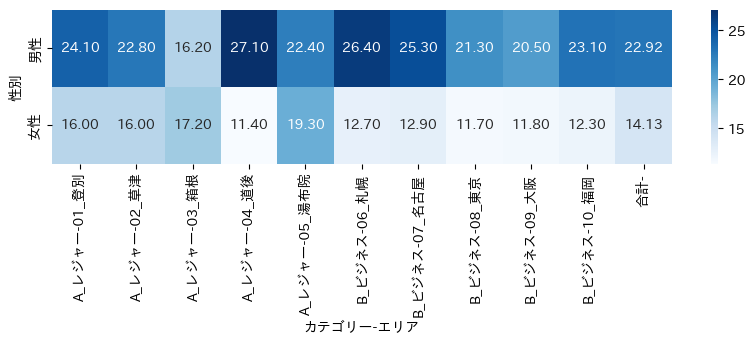

```python
import seaborn as sns
import matplotlib.pyplot as plt
import japanize_matplotlib

plt.figure(figsize=(10,2))
sns.heatmap(cross_df.loc[['男性','女性'],:], annot=True, fmt='.2f', cmap='Blues')
plt.show()
```

#### (5) 投稿者の傾向 (年代xエリア別、列ごとで100%)

```python
cross_df = pd.crosstab(df['年代'], [df['カテゴリー'],df['エリア']], margins=True, margins_name='合計', normalize='columns') * 100
display(cross_df.style.format('{:.2f}%'))
```

| カテゴリー エリア 年代 | A_レジャー 01_登別 | A_レジャー 02_草津 | A_レジャー 03_箱根 | A_レジャー 04_道後 | A_レジャー 05_湯布院 | B_ビジネス 06_札幌 | B_ビジネス 07_名古屋 | B_ビジネス 08_東京 | B_ビジネス 09_大阪 | B_ビジネス 10_福岡 | 合計 |
| --- | --- | --- | --- | --- | --- | --- | --- | --- | --- | --- | --- |
| 10代 | 0.10% | 0.00% | 0.10% | 0.00% | 0.00% | 0.00% | 0.00% | 0.10% | 0.20% | 0.00% | 0.05% |
| 120代 | 0.00% | 0.00% | 0.00% | 0.00% | 0.00% | 0.10% | 0.00% | 0.00% | 0.00% | 0.00% | 0.01% |
| 20代 | 0.80% | 3.40% | 2.60% | 1.60% | 1.90% | 2.00% | 2.50% | 0.70% | 1.60% | 1.50% | 1.86% |
| 30代 | 4.20% | 5.00% | 4.40% | 4.00% | 6.30% | 3.40% | 4.90% | 4.80% | 4.30% | 4.10% | 4.54% |
| 40代 | 8.30% | 9.00% | 7.30% | 6.70% | 10.20% | 8.20% | 8.80% | 7.10% | 9.20% | 8.20% | 8.30% |
| 50代 | 13.40% | 11.60% | 8.70% | 13.30% | 11.60% | 15.10% | 12.00% | 11.80% | 9.80% | 13.90% | 12.12% |
| 60代 | 10.70% | 8.10% | 7.60% | 10.20% | 9.90% | 9.00% | 8.50% | 7.10% | 6.10% | 5.80% | 8.30% |
| 70代 | 2.30% | 1.60% | 2.30% | 2.70% | 1.50% | 1.20% | 1.50% | 1.40% | 1.00% | 1.90% | 1.74% |
| 80代 | 0.30% | 0.10% | 0.40% | 0.00% | 0.30% | 0.10% | 0.00% | 0.00% | 0.10% | 0.00% | 0.13% |
| na | 59.90% | 61.20% | 66.60% | 61.50% | 58.30% | 60.90% | 61.80% | 67.00% | 67.70% | 64.60% | 62.95% |

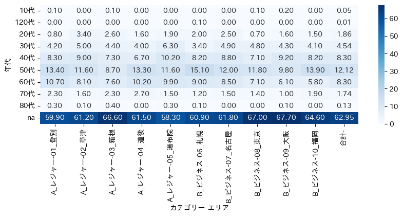

```python
import seaborn as sns
import matplotlib.pyplot as plt
import japanize_matplotlib

plt.figure(figsize=(10,3))
sns.heatmap(cross_df, annot=True, fmt='.2f', cmap='Blues')
plt.show()
```

`na` を除いてプロットする

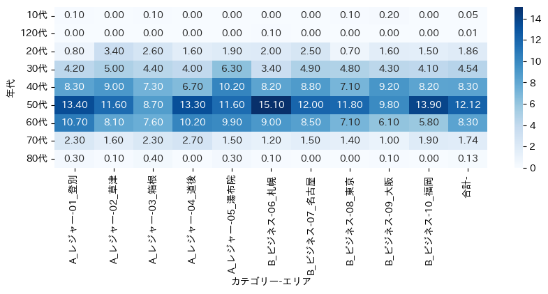

```python
import seaborn as sns
import matplotlib.pyplot as plt
import japanize_matplotlib

plt.figure(figsize=(10,3))
sns.heatmap(cross_df.loc[cross_df.index!='na',:], annot=True, fmt='.2f', cmap='Blues')
plt.show()
```

#### (6) 投稿者の傾向 (同伴者別xエリア別、列ごとで100%)

```python
cross_df = pd.crosstab(df['同伴者'], [df['カテゴリー'],df['エリア']], margins=True, margins_name='合計', normalize='columns') * 100
display(cross_df.loc[['一人','家族','恋人','友達','仕事仲間','その他'],:].style.format('{:.2f}%'))
```

| カテゴリー エリア 同伴者 | A_レジャー 01_登別 | A_レジャー 02_草津 | A_レジャー 03_箱根 | A_レジャー 04_道後 | A_レジャー 05_湯布院 | B_ビジネス 06_札幌 | B_ビジネス 07_名古屋 | B_ビジネス 08_東京 | B_ビジネス 09_大阪 | B_ビジネス 10_福岡 | 合計 |
| --- | --- | --- | --- | --- | --- | --- | --- | --- | --- | --- | --- |
| 一人 | 24.80% | 13.70% | 14.00% | 44.40% | 13.10% | 57.90% | 64.30% | 65.60% | 57.70% | 53.50% | 40.90% |
| 家族 | 63.10% | 64.30% | 66.10% | 42.70% | 69.60% | 30.90% | 24.10% | 23.40% | 29.40% | 32.10% | 44.57% |
| 恋人 | 4.80% | 14.60% | 11.20% | 4.90% | 8.30% | 4.40% | 4.20% | 4.10% | 4.40% | 3.90% | 6.48% |
| 友達 | 5.30% | 5.70% | 7.10% | 5.50% | 7.80% | 4.40% | 4.40% | 4.80% | 6.80% | 7.60% | 5.94% |
| 仕事仲間 | 1.50% | 0.70% | 0.50% | 1.80% | 0.60% | 1.90% | 2.50% | 1.30% | 1.40% | 2.40% | 1.46% |
| その他 | 0.50% | 1.00% | 1.10% | 0.70% | 0.60% | 0.50% | 0.50% | 0.80% | 0.30% | 0.50% | 0.65% |

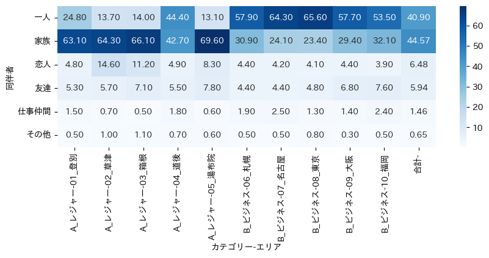

```python
import seaborn as sns
import matplotlib.pyplot as plt
import japanize_matplotlib

plt.figure(figsize=(10,3))
sns.heatmap(cross_df.loc[['一人','家族','恋人','友達','仕事仲間','その他'],:], annot=True, fmt='.2f', cmap='Blues')
plt.show()
```

#### (7) 数値評価の構成 (総合別xカテゴリ-エリア別、列ごとに100%)

```python
cross_df = pd.crosstab(df['総合'], [df['カテゴリー'],df['エリア']], margins=True, margins_name='合計', normalize='columns') * 100
display(cross_df.loc[[5,4,3,2,1],:].style.format('{:.2f}%'))
```

| カテゴリー エリア 総合 | A_レジャー 01_登別 | A_レジャー 02_草津 | A_レジャー 03_箱根 | A_レジャー 04_道後 | A_レジャー 05_湯布院 | B_ビジネス 06_札幌 | B_ビジネス 07_名古屋 | B_ビジネス 08_東京 | B_ビジネス 09_大阪 | B_ビジネス 10_福岡 | 合計 |
| --- | --- | --- | --- | --- | --- | --- | --- | --- | --- | --- | --- |
| 5 | 41.90% | 48.40% | 48.90% | 49.60% | 67.90% | 41.70% | 36.70% | 36.90% | 41.90% | 38.50% | 45.24% |
| 4 | 41.30% | 36.10% | 36.90% | 36.50% | 22.50% | 41.90% | 47.30% | 41.70% | 41.10% | 40.90% | 38.62% |
| 3 | 9.90% | 9.90% | 7.80% | 9.20% | 4.90% | 11.60% | 12.00% | 14.30% | 11.70% | 12.60% | 10.39% |
| 2 | 4.30% | 3.40% | 4.30% | 2.90% | 3.20% | 3.20% | 2.70% | 4.60% | 3.60% | 5.00% | 3.72% |
| 1 | 2.60% | 2.20% | 2.10% | 1.80% | 1.50% | 1.60% | 1.30% | 2.50% | 1.70% | 3.00% | 2.03% |

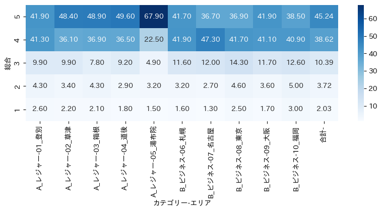

```python
import seaborn as sns
import matplotlib.pyplot as plt
import japanize_matplotlib

plt.figure(figsize=(10,3))
sns.heatmap(cross_df.loc[[5,4,3,2,1],:], annot=True, fmt='.2f', cmap='Blues')
plt.show()
```

#### (8) 数値評価の平均 (カテゴリ-エリア別x数値評価別)

```python
pivot_df = df.pivot_table(index=['カテゴリー','エリア'], values=['サービス','立地','部屋','設備・アメニティ','風呂','食事','総合'], margins=False, aggfunc='mean', dropna=True)
display(pivot_df.loc[:,['サービス','立地','部屋','設備・アメニティ','風呂','食事','総合']].style.format('{:.2f}').background_gradient(axis=None))
```

| カテゴリー | エリア | サービス | 立地 | 部屋 | 設備・アメニティ | 風呂 | 食事 | 総合 |
| --- | --- | --- | --- | --- | --- | --- | --- | --- |
| A_レジャー | 01_登別 | 4.07 | 4.21 | 3.95 | 3.90 | 4.34 | 4.08 | 4.16 |
|  | 02_草津 | 4.23 | 4.22 | 4.07 | 3.97 | 4.32 | 4.20 | 4.25 |
|  | 03_箱根 | 4.24 | 4.12 | 4.18 | 4.05 | 4.29 | 4.33 | 4.26 |
|  | 04_道後 | 4.19 | 4.41 | 4.07 | 4.00 | 4.03 | 4.19 | 4.29 |
|  | 05_湯布院 | 4.51 | 4.28 | 4.37 | 4.35 | 4.46 | 4.61 | 4.52 |
| B_ビジネス | 06_札幌 | 4.05 | 4.30 | 4.09 | 3.93 | 3.79 | 4.12 | 4.19 |
|  | 07_名古屋 | 4.00 | 4.25 | 4.04 | 3.89 | 3.75 | 4.03 | 4.15 |
|  | 08_東京 | 3.92 | 4.38 | 3.94 | 3.82 | 3.70 | 3.99 | 4.06 |
|  | 09_大阪 | 4.01 | 4.35 | 4.05 | 3.93 | 3.82 | 4.06 | 4.18 |
|  | 10_福岡 | 3.93 | 4.24 | 3.96 | 3.84 | 3.64 | 4.01 | 4.07 |

```python
pivot_df = df.pivot_table(index=['カテゴリー'], values=['サービス','立地','部屋','設備・アメニティ','風呂','食事','総合'], margins=False, aggfunc='mean', dropna=True)
display(pivot_df.loc[:,['サービス','立地','部屋','設備・アメニティ','風呂','食事','総合']].style.format('{:.2f}').background_gradient(axis=None))
```

| カテゴリー | サービス | 立地 | 部屋 | 設備・アメニティ | 風呂 | 食事 | 総合 |
| --- | --- | --- | --- | --- | --- | --- | --- |
| A_レジャー | 4.25 | 4.25 | 4.13 | 4.05 | 4.29 | 4.29 | 4.30 |
| B_ビジネス | 3.98 | 4.30 | 4.01 | 3.88 | 3.74 | 4.05 | 4.13 |

#### (9)数値評価の平均 (年代x性別)

20~30代

```python
pivot_df = df[df['年代'].isin(['20代','30代'])].pivot_table(index=['カテゴリー','性別'], values=['サービス','立地','部屋','設備・アメニティ','風呂','食事','総合'], margins=False, aggfunc='mean', dropna=True)
display(pivot_df.loc[(['A_レジャー','B_ビジネス'],['男性','女性']),['サービス','立地','部屋','設備・アメニティ','風呂','食事','総合']].style.format('{:.2f}').background_gradient(axis=None))
```

| カテゴリー | 性別 | サービス | 立地 | 部屋 | 設備・アメニティ | 風呂 | 食事 | 総合 |
| --- | --- | --- | --- | --- | --- | --- | --- | --- |
| A_レジャー | 男性 | 4.38 | 4.23 | 4.30 | 4.18 | 4.38 | 4.48 | 4.44 |
|  | 女性 | 4.55 | 4.37 | 4.38 | 4.42 | 4.45 | 4.44 | 4.47 |
| B_ビジネス | 男性 | 4.16 | 4.33 | 4.13 | 4.10 | 3.93 | 4.35 | 4.23 |
|  | 女性 | 4.19 | 4.39 | 4.24 | 4.10 | 3.93 | 4.45 | 4.32 |

40~50代

```python
pivot_df = df[df['年代'].isin(['40代','50代'])].pivot_table(index=['カテゴリー','性別'], values=['サービス','立地','部屋','設備・アメニティ','風呂','食事','総合'], margins=False, aggfunc='mean', dropna=True)
display(pivot_df.loc[(['A_レジャー','B_ビジネス'],['男性','女性']),['サービス','立地','部屋','設備・アメニティ','風呂','食事','総合']].style.format('{:.2f}').background_gradient(axis=None))
```

| カテゴリー | 性別 | サービス | 立地 | 部屋 | 設備・アメニティ | 風呂 | 食事 | 総合 |
| --- | --- | --- | --- | --- | --- | --- | --- | --- |
| A_レジャー | 男性 | 4.23 | 4.29 | 4.10 | 4.05 | 4.29 | 4.33 | 4.32 |
|  | 女性 | 4.38 | 4.38 | 4.21 | 4.17 | 4.36 | 4.37 | 4.36 |
| B_ビジネス | 男性 | 3.93 | 4.27 | 4.00 | 3.85 | 3.73 | 4.07 | 4.12 |
|  | 女性 | 4.13 | 4.36 | 4.19 | 4.02 | 3.89 | 4.13 | 4.26 |

60~80代

```python
pivot_df = df[df['年代'].isin(['60代','70代','80代'])].pivot_table(index=['カテゴリー','性別'], values=['サービス','立地','部屋','設備・アメニティ','風呂','食事','総合'], margins=False, aggfunc='mean', dropna=True)
display(pivot_df.loc[(['A_レジャー','B_ビジネス'],['男性','女性']),['サービス','立地','部屋','設備・アメニティ','風呂','食事','総合']].style.format('{:.2f}').background_gradient(axis=None))
```

| カテゴリー | 性別 | サービス | 立地 | 部屋 | 設備・アメニティ | 風呂 | 食事 | 総合 |
| --- | --- | --- | --- | --- | --- | --- | --- | --- |
| A_レジャー | 男性 | 4.21 | 4.20 | 4.05 | 3.92 | 4.26 | 4.27 | 4.27 |
|  | 女性 | 4.27 | 4.36 | 4.16 | 4.12 | 4.38 | 4.26 | 4.39 |
| B_ビジネス | 男性 | 3.91 | 4.24 | 3.98 | 3.77 | 3.75 | 3.79 | 4.13 |
|  | 女性 | 4.19 | 4.59 | 4.15 | 3.96 | 3.94 | 4.23 | 4.21 |